# Tugas Pertemuan 2

# Library

```r
library("forecast")
```

```r
library("graphics")
library("TTR")
library("TSA")
library("rio")
```

# Import Data

```r
data<-import("Data Kelompok 11.xlsx", sheet="Lembar1")
names(data)[names(data) == "CES9093161101"] <- "jmlh_pegawai"
head(data)
```

```
##   observation_date Period jmlh_pegawai
## 1       1955-01-01      1       1707.2
## 2       1955-02-01      2       1711.6
## 3       1955-03-01      3       1724.9
## 4       1955-04-01      4       1735.9
## 5       1955-05-01      5       1744.6
## 6       1955-06-01      6       1786.7
```

# Eksplorasi Data

```r
View(data)
str(data)
```

```
## 'data.frame':    171 obs. of  3 variables:
##  $ observation_date: POSIXct, format: "1955-01-01" "1955-02-01" ...
##  $ Period          : num  1 2 3 4 5 6 7 8 9 10 ...
##  $ jmlh_pegawai    : num  1707 1712 1725 1736 1745 ...
```

```r
dim(data)
```

```
## [1] 171   3
```

## Mengubah data agar terbaca sebagai data deret waktu dengan fungsi `ts()` .

```r
data.ts <- ts(data$jmlh_pegawai)
```

## Menampilkan ringkasan data.

```r
summary(data.ts)
```

```
##    Min. 1st Qu.  Median    Mean 3rd Qu.    Max.
##    1707    2126    2475    2606    3062    3746
```

## Membuat plot data deret waktu

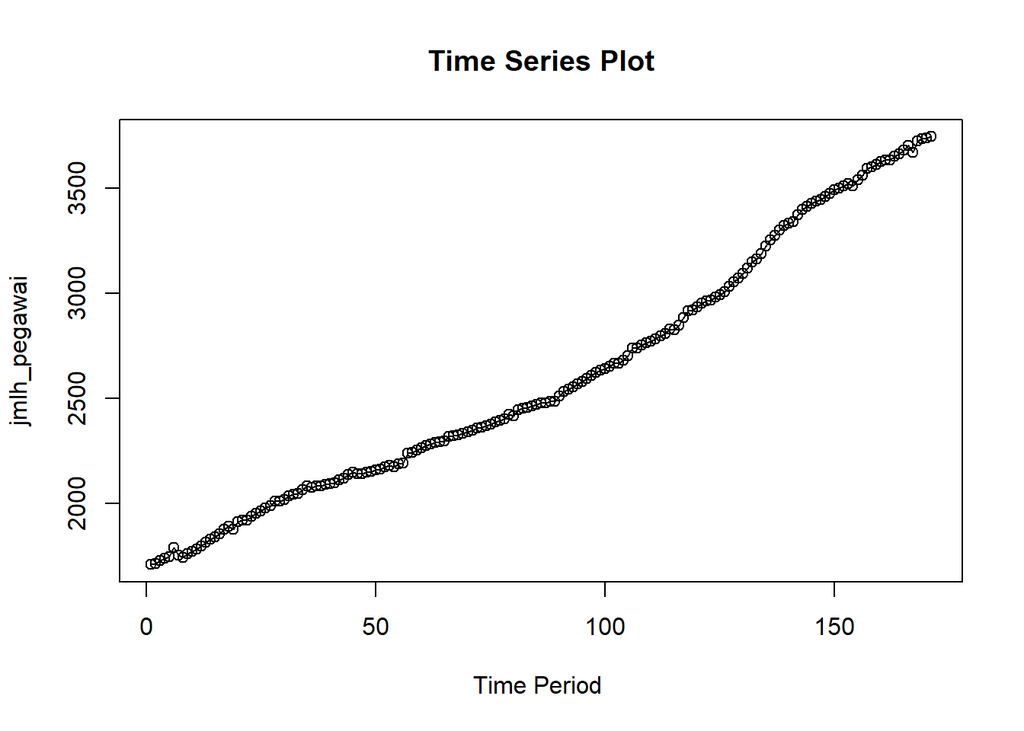

```r
ts.plot(data.ts, xlab="Time Period ", ylab="jmlh_pegawai",
        main = "Time Series Plot")
points(data.ts)
```

```r
#menyimpan plot
dev.copy(png, "plot_data.png")
```

```r
dev.off()
```

# Moving Average

## Pembagian Data

Pembagian data latih dan data uji dilakukan dengan perbandingan 80% data latih dan 20% data uji.

```r
# hitung jumlah data
n <- nrow(data)

# tentukan batas 80%
n_train <- floor(0.8 * n)

# bagi data
training_ma <- data[1:n_train, ]
testing_ma  <- data[(n_train+1):n, ]

# ubah ke time series
train_ma.ts <- ts(training_ma$jmlh_pegawai)
test_ma.ts  <- ts(testing_ma$jmlh_pegawai)
```

## Eksplorasi Keseluruhan Data, Data Latih, Data Uji

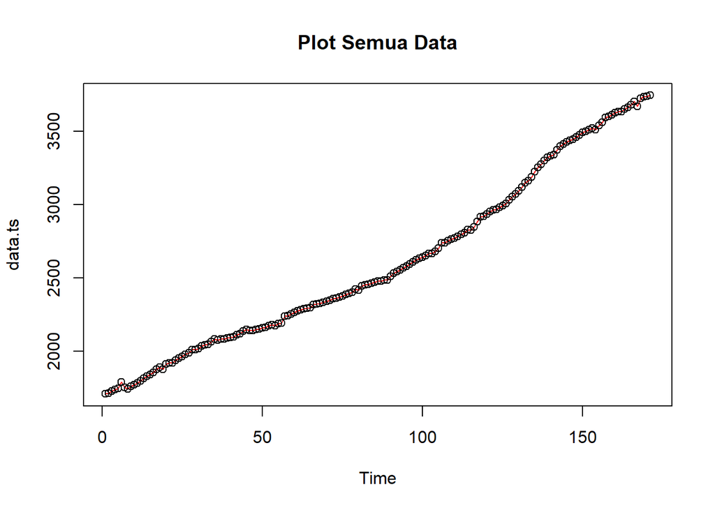

```r
#eksplorasi keseluruhan data
plot(data.ts, col="red",main="Plot Semua Data")
points(data.ts)
```

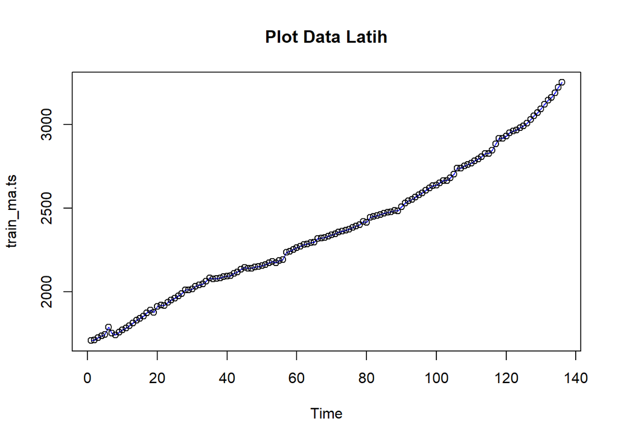

```r
#eksplorasi data latih
plot(train_ma.ts, col="blue",main="Plot Data Latih")
points(train_ma.ts)
```

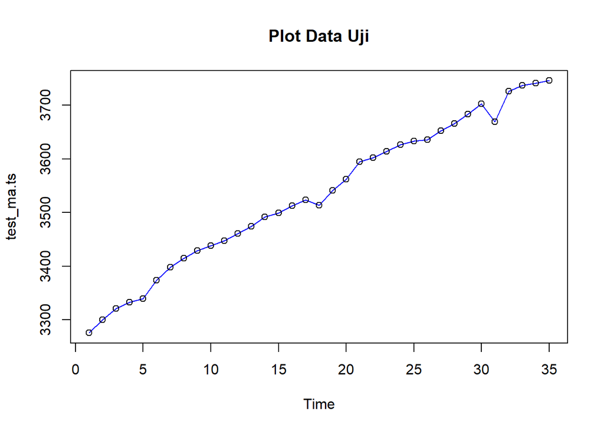

```r
#eksplorasi data uji
plot(test_ma.ts, col="blue",main="Plot Data Uji")
points(test_ma.ts)
```

## Eksplorasi Keseluruhan Data, Data Latih, Data Uji (ggplot2)

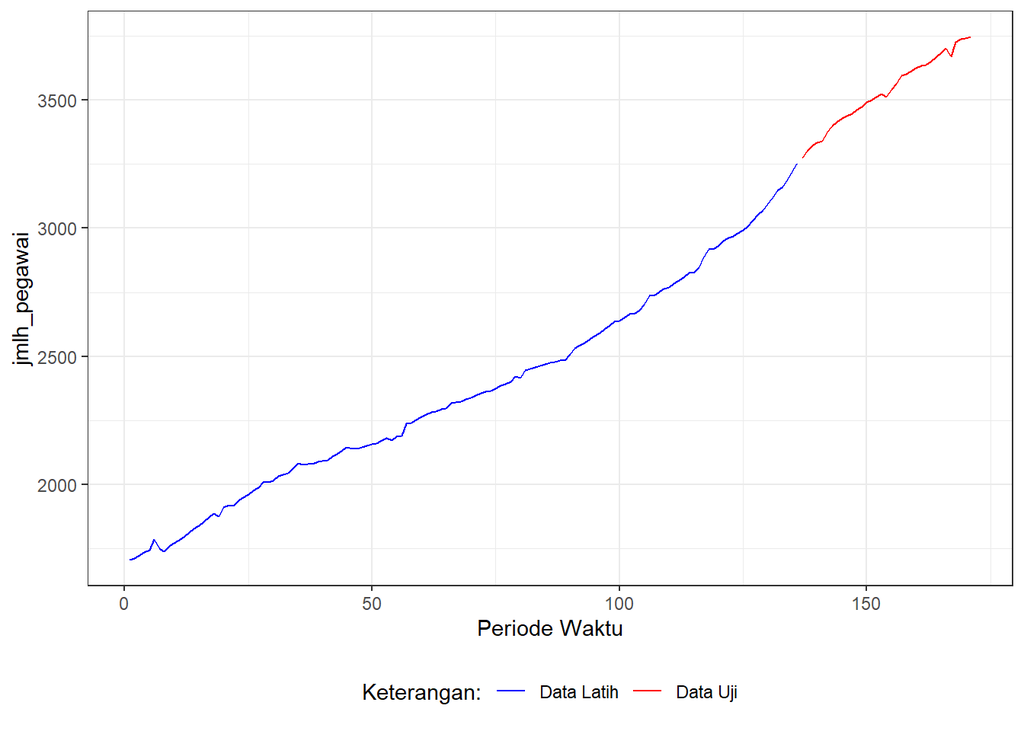

```r
library(ggplot2)
ggplot() +
  geom_line(data = training_ma, aes(x = Period, y = jmlh_pegawai, col = "Data Latih")) +
  geom_line(data = testing_ma, aes(x = Period, y = jmlh_pegawai, col = "Data Uji")) +
  labs(x = "Periode Waktu", y = "jmlh_pegawai", color = "Legend") +
   scale_colour_manual(name="Keterangan:", breaks = c("Data Latih", "Data Uji"),
                      values = c("blue", "red")) +
  theme_bw() + theme(legend.position = "bottom",
                     plot.caption = element_text(hjust=0.5, size=12))
```

### Single Moving Average (SMA)

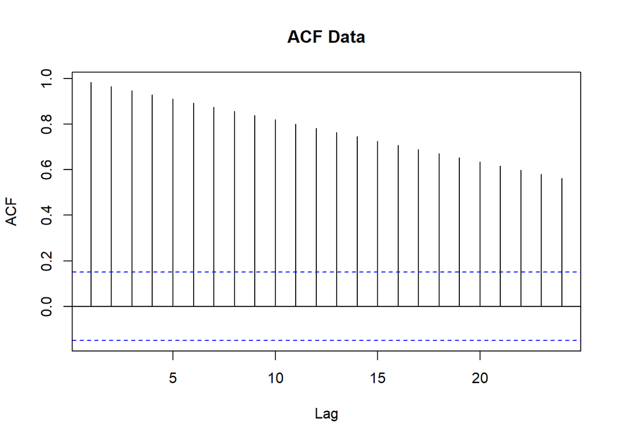

```r
acf(data.ts, lag.max = 24, main = "ACF Data")
```

Dari grafik ACF, semua nilai ACF posiif dan turun secara perlahan dari lag 1 sampai lag 24, tidak ada lonjakan khusus di lag tertentu. Data memiliki pola tren, bukan pola musiman. Metode SMA tetap dilakukan dengan meninjau `m` berapa yang menghasilkan MSE data uji paling kecil.

```r
m_values <- c(3, 4, 6, 12)

hasil_sma <- data.frame(m = m_values, MSE_train = NA, MSE_test = NA)

for (i in seq_along(m_values)) {
  m <- m_values[i]

  sma_i   <- SMA(train_ma.ts, n = m)
  ramal_i <- c(NA, sma_i)

  # akurasi data latih (warmup = m+1 periode pertama)
  error_train <- train_ma.ts - ramal_i[1:length(train_ma.ts)]
  MSE_train   <- mean(error_train[(m+1):length(train_ma.ts)]^2)

  # akurasi data uji (forecast SMA konstan = nilai pemulusan terakhir)
  n_test_sma   <- length(test_ma.ts)
  ramalan_test <- rep(ramal_i[length(ramal_i)], n_test_sma)
  error_test   <- test_ma.ts - ramalan_test
  MSE_test     <- mean(error_test^2)

  hasil_sma$MSE_train[i] <- MSE_train
  hasil_sma$MSE_test[i]  <- MSE_test
}

hasil_sma
```

```
##    m MSE_train MSE_test
## 1  3  700.2244 115542.5
## 2  4 1031.0016 125098.3
## 3  6 1869.9342 141641.4
## 4 12 5981.0186 196009.9
```

Dalam hal ini akan dilakukan pemulusan dengan parameter `m=3`.

```r
data.sma<-SMA(train_ma.ts, n=3)
data.sma
```

```
## Time Series:
## Start = 1
## End = 136
## Frequency = 1
##   [1]       NA       NA 1714.567 1724.133 1735.133 1755.733 1761.100 1759.367
##   [9] 1750.000 1756.100 1770.333 1782.867 1797.100 1812.433 1826.967 1840.767
##  [17] 1855.967 1872.100 1879.167 1891.500 1901.833 1915.833 1924.667 1935.033
##  [25] 1949.333 1962.233 1975.067 1991.367 2002.900 2012.000 2019.933 2029.767
##  [33] 2039.600 2049.833 2064.033 2074.133 2079.533 2079.167 2083.867 2087.900
##  [41] 2092.800 2099.133 2107.700 2120.667 2132.733 2139.833 2141.800 2142.300
##  [49] 2146.467 2151.900 2156.967 2163.967 2171.833 2175.200 2180.000 2183.400
##  [57] 2204.900 2222.733 2243.100 2252.167 2262.800 2272.833 2280.500 2287.533
##  [65] 2292.333 2302.967 2312.200 2321.600 2326.533 2332.500 2340.000 2348.133
##  [73] 2355.700 2362.133 2367.533 2375.333 2383.967 2392.867 2404.933 2412.467
##  [81] 2427.300 2437.033 2451.000 2456.867 2463.500 2469.600 2474.867 2479.933
##  [89] 2483.100 2493.300 2508.400 2527.933 2542.700 2554.800 2566.567 2579.400
##  [97] 2592.733 2607.233 2621.567 2632.067 2641.500 2651.500 2660.667 2671.000
## [105] 2683.500 2707.467 2726.400 2743.267 2751.333 2762.133 2772.167 2783.033
## [113] 2795.700 2810.467 2820.967 2833.633 2852.667 2882.833 2907.067 2923.167
## [121] 2934.800 2949.033 2960.800 2970.800 2981.333 2994.833 3011.300 3031.067
## [129] 3051.867 3072.967 3095.600 3121.000 3143.600 3166.467 3192.333 3222.467
```

```r
data.ramal<-c(NA,data.sma)
data.ramal #forecast 1 periode ke depan
```

```
##   [1]       NA       NA       NA 1714.567 1724.133 1735.133 1755.733 1761.100
##   [9] 1759.367 1750.000 1756.100 1770.333 1782.867 1797.100 1812.433 1826.967
##  [17] 1840.767 1855.967 1872.100 1879.167 1891.500 1901.833 1915.833 1924.667
##  [25] 1935.033 1949.333 1962.233 1975.067 1991.367 2002.900 2012.000 2019.933
##  [33] 2029.767 2039.600 2049.833 2064.033 2074.133 2079.533 2079.167 2083.867
##  [41] 2087.900 2092.800 2099.133 2107.700 2120.667 2132.733 2139.833 2141.800
##  [49] 2142.300 2146.467 2151.900 2156.967 2163.967 2171.833 2175.200 2180.000
##  [57] 2183.400 2204.900 2222.733 2243.100 2252.167 2262.800 2272.833 2280.500
##  [65] 2287.533 2292.333 2302.967 2312.200 2321.600 2326.533 2332.500 2340.000
##  [73] 2348.133 2355.700 2362.133 2367.533 2375.333 2383.967 2392.867 2404.933
##  [81] 2412.467 2427.300 2437.033 2451.000 2456.867 2463.500 2469.600 2474.867
##  [89] 2479.933 2483.100 2493.300 2508.400 2527.933 2542.700 2554.800 2566.567
##  [97] 2579.400 2592.733 2607.233 2621.567 2632.067 2641.500 2651.500 2660.667
## [105] 2671.000 2683.500 2707.467 2726.400 2743.267 2751.333 2762.133 2772.167
## [113] 2783.033 2795.700 2810.467 2820.967 2833.633 2852.667 2882.833 2907.067
## [121] 2923.167 2934.800 2949.033 2960.800 2970.800 2981.333 2994.833 3011.300
## [129] 3031.067 3051.867 3072.967 3095.600 3121.000 3143.600 3166.467 3192.333
## [137] 3222.467
```

Selanjutnya dilakukan peramalan sebanyak 35 periode sesuai dengan jumlah data uji.

```r
data.gab <- cbind(
  aktual=c(data.ts),
  pemulusan=c(data.sma, rep(NA, 35)),
  ramalan=c(data.ramal, rep(data.ramal[length(data.ramal)], 34)))

data.gab #forecast 35 periode ke depan
```

```
##        aktual pemulusan  ramalan
##   [1,] 1707.2        NA       NA
##   [2,] 1711.6        NA       NA
##   [3,] 1724.9  1714.567       NA
##   [4,] 1735.9  1724.133 1714.567
##   [5,] 1744.6  1735.133 1724.133
##   [6,] 1786.7  1755.733 1735.133
##   [7,] 1752.0  1761.100 1755.733
##   [8,] 1739.4  1759.367 1761.100
##   [9,] 1758.6  1750.000 1759.367
##  [10,] 1770.3  1756.100 1750.000
##  [11,] 1782.1  1770.333 1756.100
##  [12,] 1796.2  1782.867 1770.333
##  [13,] 1813.0  1797.100 1782.867
##  [14,] 1828.1  1812.433 1797.100
```

[output cut: 157 more lines]

Adapun plot data deret waktu dari hasil peramalan yang dilakukan adalah sebagai berikut.

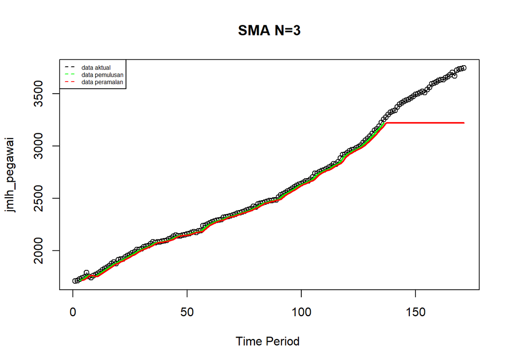

```r
ts.plot(data.ts, xlab="Time Period ", ylab="jmlh_pegawai", main= "SMA N=3")
points(data.ts)
lines(data.gab[,2],col="green",lwd=2)
lines(data.gab[,3],col="red",lwd=2)
legend("topleft",c("data aktual","data pemulusan","data peramalan"), lty=8, col=c("black","green","red"), cex=0.5)
```

Selanjutnya perhitungan akurasi dilakukan dengan ukuran akurasi *Sum Squares Error* (SSE), *Mean Square Error* (MSE) dan *Mean Absolute Percentage Error* (MAPE). Perhitungan akurasi dilakukan baik pada data latih maupun pada data uji.

#### Akurasi Data Latih

```r
#Menghitung nilai keakuratan data latih
error_train.sma = train_ma.ts-data.ramal[1:length(train_ma.ts)]

SSE_train.sma = sum(error_train.sma[4:length(train_ma.ts)]^2)
MSE_train.sma = mean(error_train.sma[4:length(train_ma.ts)]^2)
MAPE_train.sma = mean(abs((error_train.sma[4:length(train_ma.ts)]/train_ma.ts[4:length(train_ma.ts)])*100))

akurasi_train.sma <- matrix(c(SSE_train.sma, MSE_train.sma, MAPE_train.sma))
row.names(akurasi_train.sma)<- c("SSE", "MSE", "MAPE")
colnames(akurasi_train.sma) <- c("Akurasi m = 3")
akurasi_train.sma
```

```
##      Akurasi m = 3
## SSE   9.312985e+04
## MSE   7.002244e+02
## MAPE  9.665839e-01
```

Dalam hal ini nilai MAPE data latih pada metode pemulusan SMA sekitar 0.966%, nilai ini dapat dikategorikan sebagai nilai akurasi yang sangat baik. Selanjutnya dilakukan perhitungan nilai MAPE data uji pada metode pemulusan SMA.

#### Akurasi Data Uji

```r
#Menghitung nilai keakuratan data uji
error_test.sma = test_ma.ts-data.gab[137:171,3]

SSE_test.sma = sum(error_test.sma^2)
MSE_test.sma = mean(error_test.sma^2)
MAPE_test.sma = mean(abs((error_test.sma/test_ma.ts*100)))

akurasi_test.sma <- matrix(c(SSE_test.sma, MSE_test.sma, MAPE_test.sma))
row.names(akurasi_test.sma)<- c("SSE", "MSE", "MAPE")
colnames(akurasi_test.sma) <- c("Akurasi m = 3")
akurasi_test.sma
```

```
##      Akurasi m = 3
## SSE   4.043988e+06
## MSE   1.155425e+05
## MAPE  8.669179e+00
```

### Double Moving Average (DMA)

```r
dma <- SMA(data.sma, n = 3)
At <- 2*data.sma - dma
Bt <- 2/(3-1)*(data.sma - dma)
data.dma<- At+Bt
data.ramal2<- c(NA, data.dma)

t = 1:35
f = c()

for (i in t) {
  f[i] = At[length(At)] + Bt[length(Bt)]*(i)
}

data.gab2 <- cbind(aktual = c(data.ts),
                   pemulusan1 = c(data.sma,rep(NA,35)),
                   pemulusan2 = c(dma, rep(NA,35)),
                   At = c(At, rep(NA,35)),
                   Bt = c(Bt,rep(NA,35)),
                   ramalan = c(data.ramal2, f[-1]))
data.gab2
```

```
##        aktual pemulusan1 pemulusan2       At         Bt  ramalan
##   [1,] 1707.2         NA         NA       NA         NA       NA
##   [2,] 1711.6         NA         NA       NA         NA       NA
##   [3,] 1724.9   1714.567         NA       NA         NA       NA
##   [4,] 1735.9   1724.133         NA       NA         NA       NA
##   [5,] 1744.6   1735.133   1724.611 1745.656 10.5222222       NA
##   [6,] 1786.7   1755.733   1738.333 1773.133 17.4000000 1756.178
##   [7,] 1752.0   1761.100   1750.656 1771.544 10.4444444 1790.533
##   [8,] 1739.4   1759.367   1758.733 1760.000  0.6333333 1781.989
##   [9,] 1758.6   1750.000   1756.822 1743.178 -6.8222222 1760.633
##  [10,] 1770.3   1756.100   1755.156 1757.044  0.9444444 1736.356
##  [11,] 1782.1   1770.333   1758.811 1781.856 11.5222222 1757.989
##  [12,] 1796.2   1782.867   1769.767 1795.967 13.1000000 1793.378
##  [13,] 1813.0   1797.100   1783.433 1810.767 13.6666667 1809.067
##  [14,] 1828.1   1812.433   1797.467 1827.400 14.9666667 1824.433
```

[output cut: 157 more lines]

Hasil pemulusan menggunakan metode DMA divisualisasikan sebagai berikut

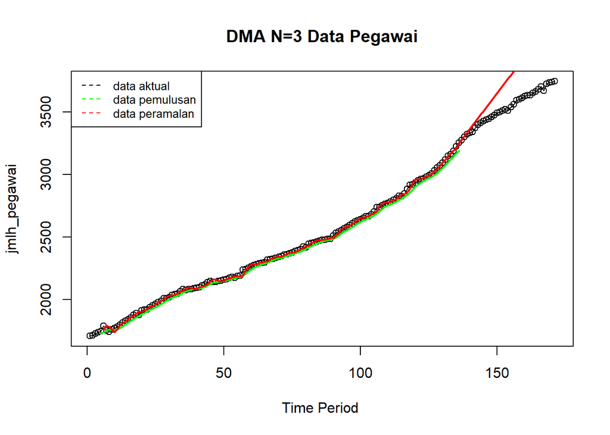

```r
ts.plot(data.ts, xlab="Time Period ", ylab="jmlh_pegawai", main= "DMA N=3 Data Pegawai")
points(data.ts)
lines(data.gab2[,3],col="green",lwd=2)
lines(data.gab2[,6],col="red",lwd=2)
legend("topleft",c("data aktual","data pemulusan","data peramalan"), lty=8, col=c("black","green","red"), cex=0.8)
```

Selanjutnya perhitungan akurasi dilakukan baik pada data latih maupun data uji. Perhitungan akurasi dilakukan dengan ukuran akurasi SSE, MSE dan MAPE.

#### Akurasi Data Latih

```r
#Menghitung nilai keakuratan data latih
error_train.dma = train_ma.ts-data.ramal2[1:length(train_ma.ts)]

SSE_train.dma = sum(error_train.dma[6:length(train_ma.ts)]^2)
MSE_train.dma = mean(error_train.dma[6:length(train_ma.ts)]^2)
MAPE_train.dma = mean(abs((error_train.dma[6:length(train_ma.ts)]/train_ma.ts[6:length(train_ma.ts)])*100))

akurasi_train.dma <- matrix(c(SSE_train.dma, MSE_train.dma, MAPE_train.dma))
row.names(akurasi_train.dma)<- c("SSE", "MSE", "MAPE")
colnames(akurasi_train.dma) <- c("Akurasi m = 3")
akurasi_train.dma
```

```
##      Akurasi m = 3
## SSE   2.007489e+04
## MSE   1.532435e+02
## MAPE  3.769494e-01
```

Perhitungan akurasi pada data latih menggunakan nilai MAPE menghasilkan nilai MAPE 0.377% yang kurang dari 10% sehingga dikategorikan sangat baik. Selanjutnya, perhitungan nilai akurasi dilakukan pada data uji.

#### Akurasi Data Uji

```r
#Menghitung nilai keakuratan data uji
error_test.dma = test_ma.ts-data.gab2[137:171,6]
SSE_test.dma = sum(error_test.dma^2)
MSE_test.dma = mean(error_test.dma^2)
MAPE_test.dma = mean(abs((error_test.dma/test_ma.ts*100)))

akurasi_test.dma <- matrix(c(SSE_test.dma, MSE_test.dma, MAPE_test.dma))
row.names(akurasi_test.dma)<- c("SSE", "MSE", "MAPE")
colnames(akurasi_test.dma) <- c("Akurasi m = 3")
akurasi_test.dma
```

```
##      Akurasi m = 3
## SSE   2.757156e+06
## MSE   7.877589e+04
## MAPE  6.473561e+00
```

Pada data latih dan data uji, metode DMA lebih baik dibandingkan dengan metode SMA.

## Exponential Smoothing

### Pembagian Data

Pembagian data latih dan data uji dilakukan dengan perbandingan 80% data latih dan 20% data uji.

```r
# jumlah baris data
n <- nrow(data)

# hitung batas 80%
n_train <- floor(0.8 * n)

# bagi data
training <- data[1:n_train, ]
testing  <- data[(n_train+1):n, ]

# ubah ke time series
train.ts <- ts(training$jmlh_pegawai)
test.ts  <- ts(testing$jmlh_pegawai)
```

### Eksplorasi

Eksplorasi dilakukan dengan membuat plot data deret waktu untuk keseluruhan data, data latih, dan data uji.

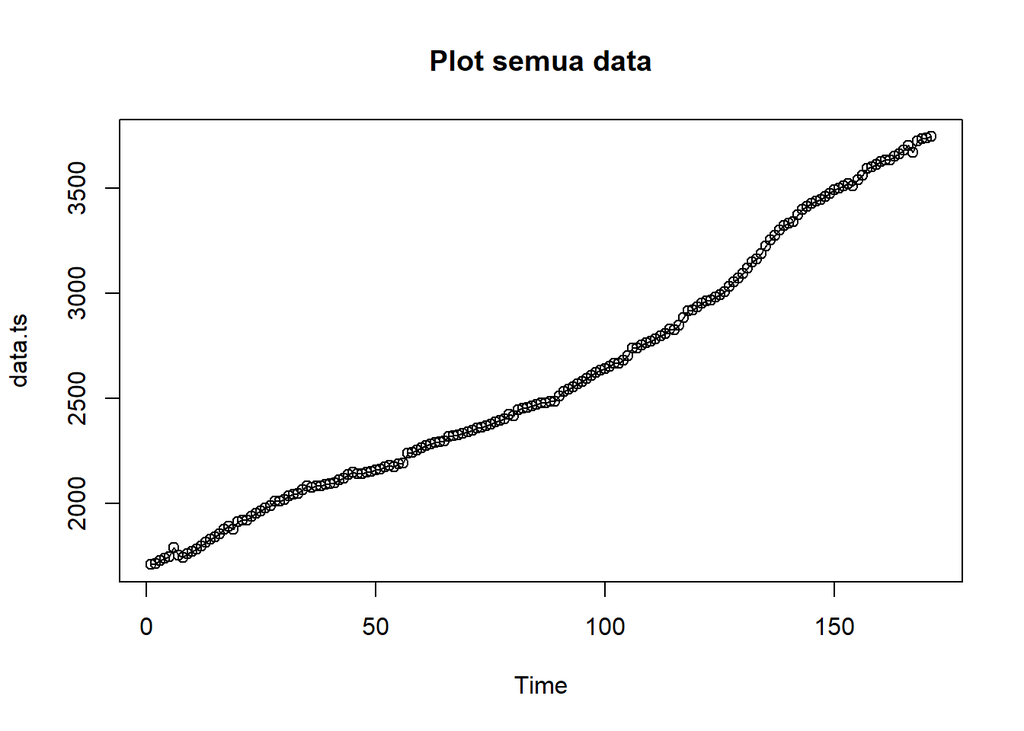

```r
#eksplorasi data
plot(data.ts, col="black",main="Plot semua data")
points(data.ts)
```

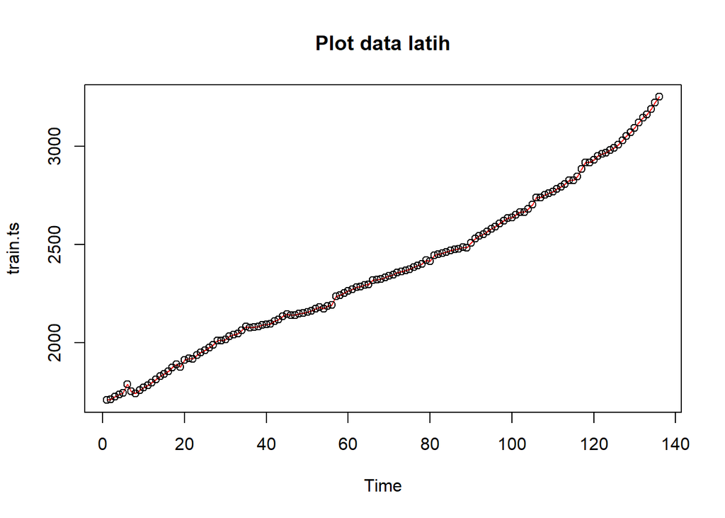

```r
plot(train.ts, col="red",main="Plot data latih")
points(train.ts)
```

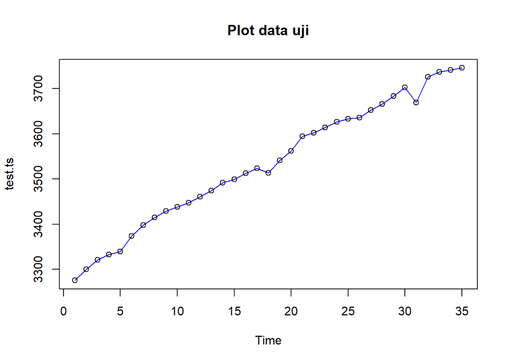

```r
plot(test.ts, col="blue",main="Plot data uji")
points(test.ts)
```

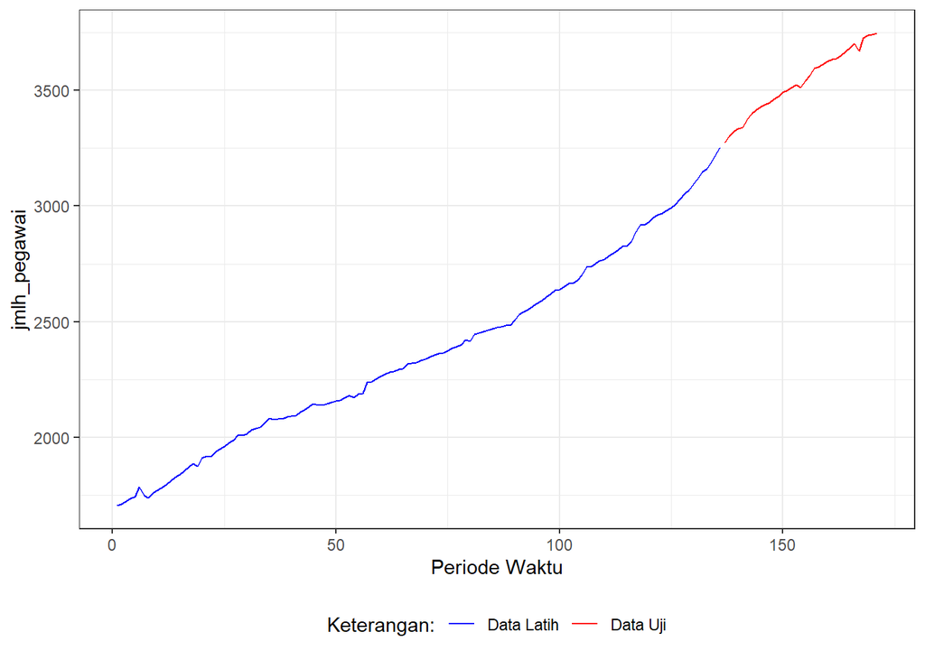

```r
#Eksplorasi dengan GGPLOT
library(ggplot2)
ggplot() +
  geom_line(data = training, aes(x = Period, y = jmlh_pegawai, col = "Data Latih")) +
  geom_line(data = testing, aes(x = Period, y = jmlh_pegawai, col = "Data Uji")) +
  labs(x = "Periode Waktu", y = "jmlh_pegawai", color = "Legend") +
  scale_colour_manual(name="Keterangan:", breaks = c("Data Latih", "Data Uji"),
                      values = c("blue", "red")) +
  theme_bw() + theme(legend.position = "bottom",
                     plot.caption = element_text(hjust=0.5, size=12))
```

### Single Exponential Smoothing (SES)

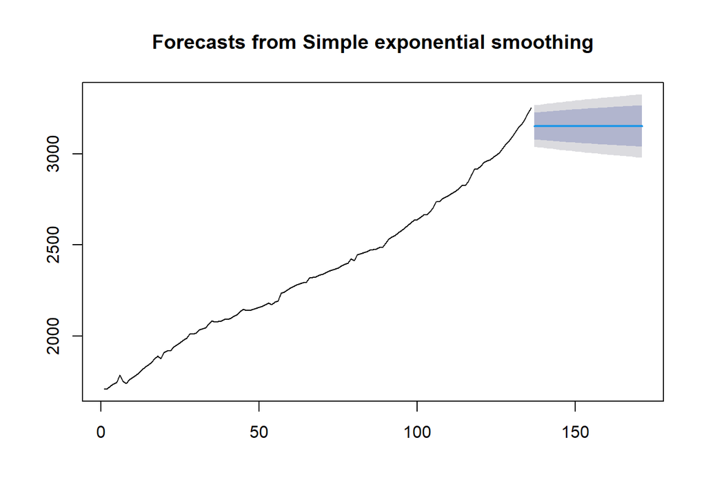

```r
#Cara 1 (fungsi ses)
ses.1 <- ses(train.ts, h = 35, alpha = 0.2)
plot(ses.1)
```

```r
ses.1
```

```
##     Point Forecast    Lo 80    Hi 80    Lo 95    Hi 95
## 137       3153.132 3079.107 3227.156 3039.922 3266.341
## 138       3153.132 3077.642 3228.621 3037.680 3268.583
## 139       3153.132 3076.203 3230.060 3035.480 3270.783
## 140       3153.132 3074.792 3231.471 3033.321 3272.942
## 141       3153.132 3073.405 3232.858 3031.201 3275.062
## 142       3153.132 3072.042 3234.221 3029.116 3277.147
## 143       3153.132 3070.702 3235.561 3027.066 3279.197
## 144       3153.132 3069.383 3236.880 3025.049 3281.214
## 145       3153.132 3068.084 3238.179 3023.063 3283.200
## 146       3153.132 3066.805 3239.458 3021.107 3285.156
## 147       3153.132 3065.545 3240.718 3019.180 3287.083
## 148       3153.132 3064.303 3241.960 3017.280 3288.983
## 149       3153.132 3063.077 3243.186 3015.406 3290.857
## 150       3153.132 3061.869 3244.394 3013.557 3292.706
```

[output cut: 21 more lines]

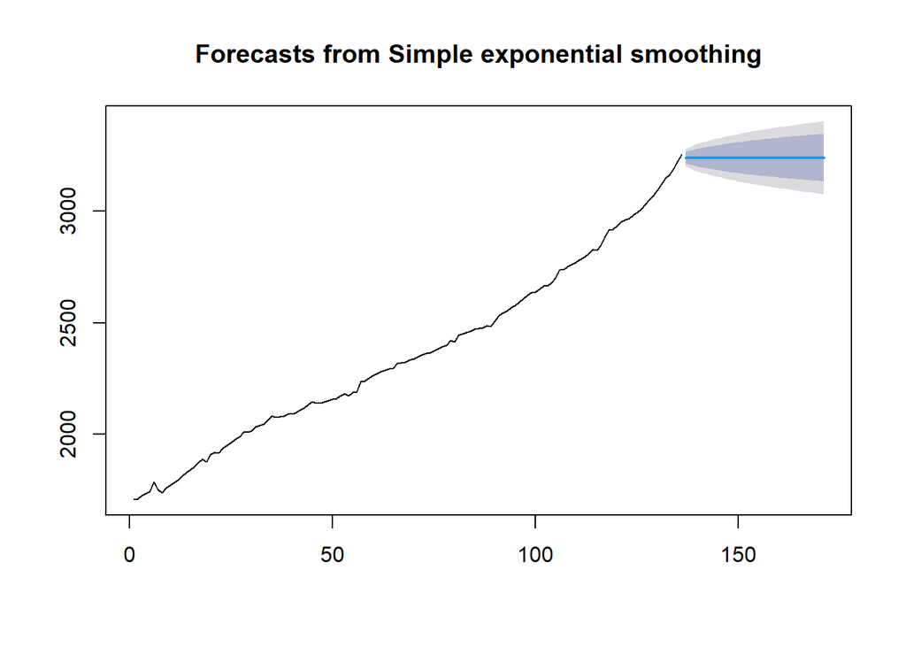

```r
ses.2 <- ses(train.ts, h = 35, alpha = 0.7)
plot(ses.2)
```

```r
ses.2
```

```
##     Point Forecast    Lo 80    Hi 80    Lo 95    Hi 95
## 137       3240.378 3214.943 3265.813 3201.478 3279.278
## 138       3240.378 3209.330 3271.426 3192.895 3287.862
## 139       3240.378 3204.588 3276.169 3185.641 3295.115
## 140       3240.378 3200.403 3280.353 3179.242 3301.514
## 141       3240.378 3196.618 3284.139 3173.452 3307.304
## 142       3240.378 3193.134 3287.622 3168.125 3312.632
## 143       3240.378 3189.891 3290.866 3163.164 3317.592
## 144       3240.378 3186.843 3293.913 3158.503 3322.253
## 145       3240.378 3183.960 3296.796 3154.094 3326.662
## 146       3240.378 3181.217 3299.539 3149.899 3330.857
## 147       3240.378 3178.596 3302.160 3145.891 3334.866
## 148       3240.378 3176.082 3304.675 3142.045 3338.711
## 149       3240.378 3173.662 3307.094 3138.345 3342.412
## 150       3240.378 3171.327 3309.429 3134.774 3345.983
```

[output cut: 21 more lines]

Untuk mendapatkan gambar hasil pemulusan pada data latih dengan fungsi `ses()` , perlu digunakan fungsi `autoplot()` dan `autolayer()` dari *library packages* `ggplot2` .

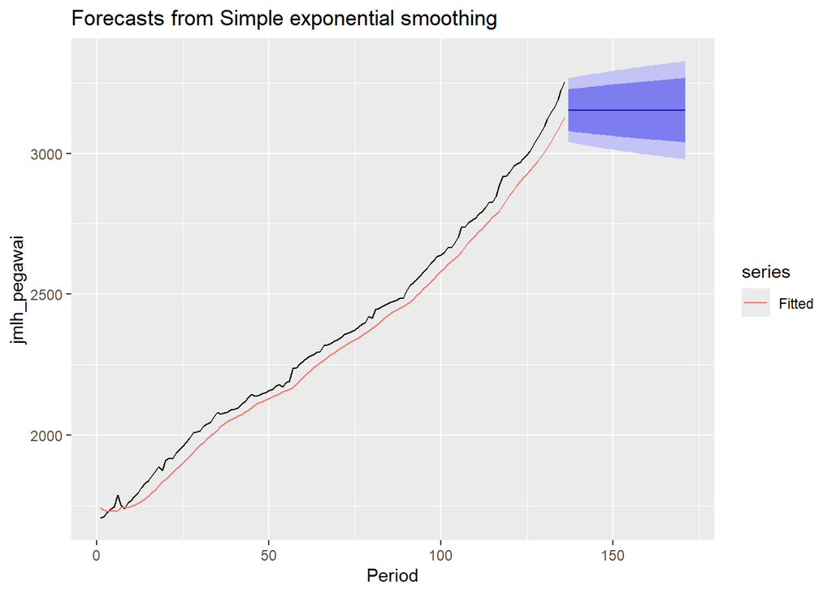

```r
autoplot(ses.1) +
  autolayer(fitted(ses.1), series="Fitted") +
  ylab("jmlh_pegawai") + xlab("Period")
```

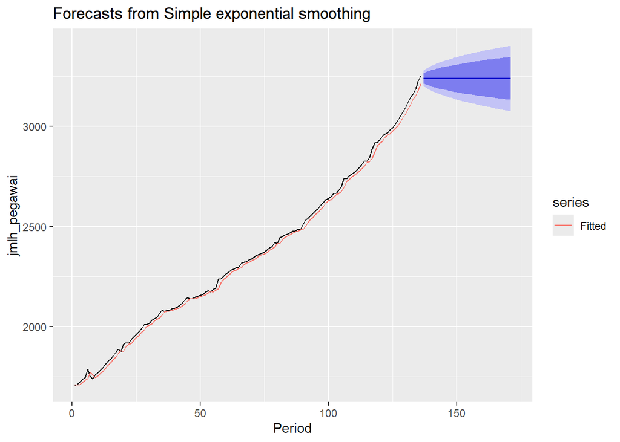

```r
autoplot(ses.2) +
  autolayer(fitted(ses.2), series="Fitted") +
  ylab("jmlh_pegawai") + xlab("Period")
```

Selanjutnya akan digunakan fungsi `HoltWinters()` dengan nilai inisialisasi parameter dan panjang periode peramalan yang sama dengan fungsi `ses()` .

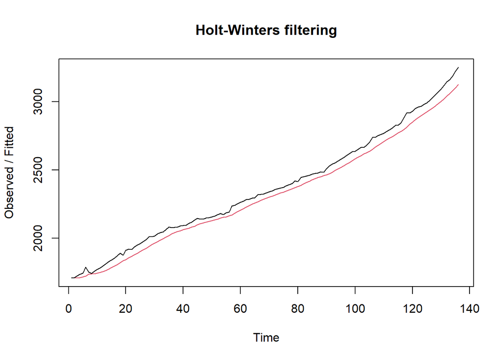

```r
#Cara 2 (fungsi Holtwinter)
ses1<- HoltWinters(train.ts, gamma = FALSE, beta = FALSE, alpha = 0.2)
plot(ses1)
```

```r
#ramalan
ramalan1<- forecast(ses1, h=35)
ramalan1
```

```
##     Point Forecast    Lo 80    Hi 80    Lo 95    Hi 95
## 137       3153.132 3125.264 3180.999 3110.512 3195.751
## 138       3153.132 3124.712 3181.551 3109.668 3196.595
## 139       3153.132 3124.171 3182.092 3108.840 3197.423
## 140       3153.132 3123.639 3182.624 3108.027 3198.236
## 141       3153.132 3123.117 3183.146 3107.229 3199.034
## 142       3153.132 3122.604 3183.659 3106.444 3199.819
## 143       3153.132 3122.100 3184.163 3105.673 3200.590
## 144       3153.132 3121.603 3184.660 3104.913 3201.350
## 145       3153.132 3121.114 3185.149 3104.166 3202.097
## 146       3153.132 3120.633 3185.630 3103.429 3202.834
## 147       3153.132 3120.158 3186.105 3102.704 3203.559
## 148       3153.132 3119.691 3186.572 3101.988 3204.275
## 149       3153.132 3119.229 3187.034 3101.283 3204.980
## 150       3153.132 3118.774 3187.489 3100.587 3205.676
```

[output cut: 21 more lines]

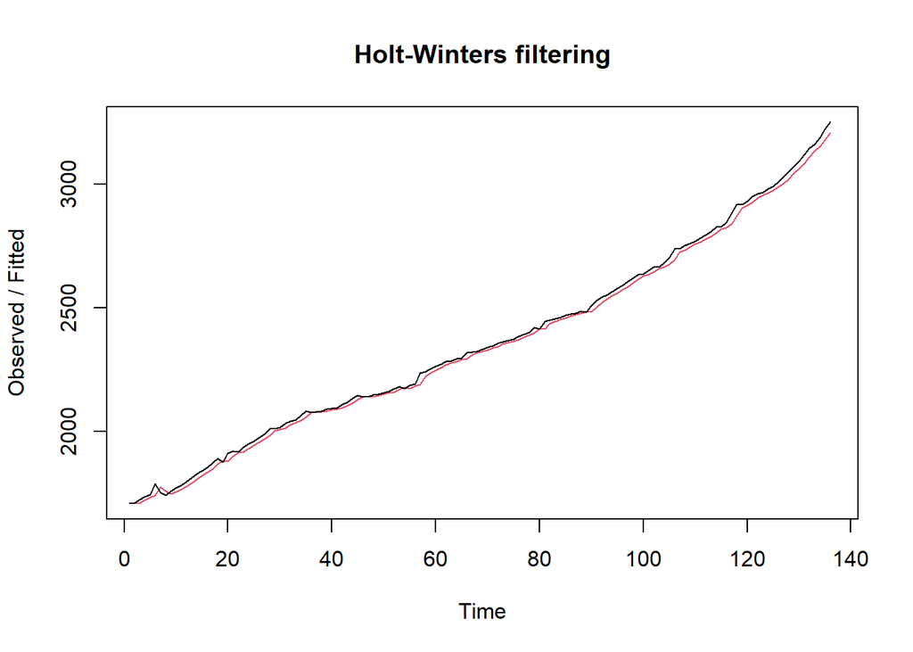

```r
ses2<- HoltWinters(train.ts, gamma = FALSE, beta = FALSE, alpha = 0.7)
plot(ses2)
```

```r
#ramalan
ramalan2<- forecast(ses2, h=35)
ramalan2
```

```
##     Point Forecast    Lo 80    Hi 80    Lo 95    Hi 95
## 137       3240.378 3225.834 3254.922 3218.135 3262.622
## 138       3240.378 3222.625 3258.132 3213.226 3267.530
## 139       3240.378 3219.912 3260.844 3209.079 3271.678
## 140       3240.378 3217.520 3263.236 3205.420 3275.337
## 141       3240.378 3215.355 3265.401 3202.109 3278.648
## 142       3240.378 3213.363 3267.393 3199.062 3281.694
## 143       3240.378 3211.508 3269.248 3196.226 3284.531
## 144       3240.378 3209.766 3270.990 3193.561 3287.196
## 145       3240.378 3208.117 3272.639 3191.039 3289.717
## 146       3240.378 3206.549 3274.207 3188.641 3292.116
## 147       3240.378 3205.050 3275.706 3186.349 3294.408
## 148       3240.378 3203.612 3277.144 3184.150 3296.607
## 149       3240.378 3202.229 3278.528 3182.034 3298.723
## 150       3240.378 3200.894 3279.863 3179.992 3300.765
```

[output cut: 21 more lines]

Jika menggunakan nilai parameter $\alpha$ yang optimum.

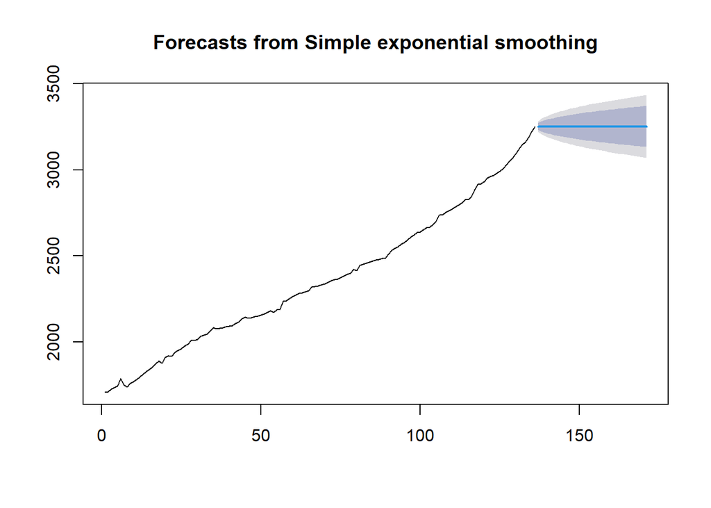

```r
#SES
ses.opt <- ses(train.ts, h = 35, alpha = NULL)
plot(ses.opt)
```

```r
ses.opt
```

```
##     Point Forecast    Lo 80    Hi 80    Lo 95    Hi 95
## 137       3252.897 3232.788 3273.006 3222.143 3283.651
## 138       3252.897 3224.460 3281.334 3209.406 3296.388
## 139       3252.897 3218.069 3287.725 3199.633 3306.162
## 140       3252.897 3212.682 3293.112 3191.393 3314.401
## 141       3252.897 3207.935 3297.859 3184.134 3321.660
## 142       3252.897 3203.644 3302.150 3177.571 3328.223
## 143       3252.897 3199.698 3306.096 3171.536 3334.258
## 144       3252.897 3196.025 3309.769 3165.919 3339.876
## 145       3252.897 3192.575 3313.219 3160.643 3345.152
## 146       3252.897 3189.312 3316.482 3155.652 3350.142
## 147       3252.897 3186.209 3319.586 3150.906 3354.888
## 148       3252.897 3183.244 3322.551 3146.371 3359.423
## 149       3252.897 3180.399 3325.395 3142.021 3363.773
## 150       3252.897 3177.663 3328.132 3137.836 3367.958
```

[output cut: 21 more lines]

```r
#Lamda Optimum Holt Winter
HWopt<- HoltWinters(train.ts, gamma = FALSE, beta = FALSE, alpha = NULL)
HWopt
```

```
## Holt-Winters exponential smoothing without trend and without seasonal component.
##
## Call:
## HoltWinters(x = train.ts, alpha = NULL, beta = FALSE, gamma = FALSE)
##
## Smoothing parameters:
##  alpha: 0.9999489
##  beta : FALSE
##  gamma: FALSE
##
## Coefficients:
##       [,1]
## a 3252.899
```

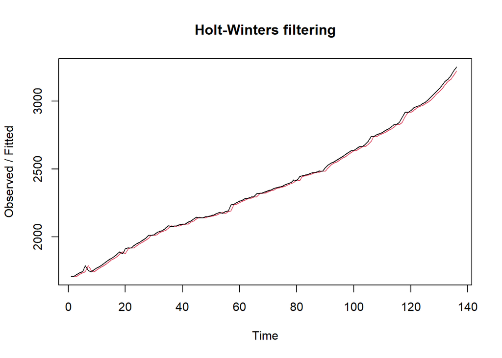

```r
plot(HWopt)
```

```r
#ramalan
ramalanopt<- forecast(HWopt, h=35)
ramalanopt
```

```
##     Point Forecast    Lo 80    Hi 80    Lo 95    Hi 95
## 137       3252.899 3239.208 3266.589 3231.961 3273.836
## 138       3252.899 3233.538 3272.259 3223.289 3282.508
## 139       3252.899 3229.187 3276.610 3216.635 3289.162
## 140       3252.899 3225.519 3280.278 3211.025 3294.772
## 141       3252.899 3222.288 3283.510 3206.083 3299.714
## 142       3252.899 3219.366 3286.431 3201.615 3304.182
## 143       3252.899 3216.679 3289.118 3197.506 3308.291
## 144       3252.899 3214.179 3291.619 3193.681 3312.116
## 145       3252.899 3211.830 3293.967 3190.089 3315.708
## 146       3252.899 3209.608 3296.189 3186.692 3319.105
## 147       3252.899 3207.495 3298.302 3183.460 3322.337
## 148       3252.899 3205.477 3300.321 3180.373 3325.424
## 149       3252.899 3203.540 3302.257 3177.411 3328.386
## 150       3252.899 3201.677 3304.120 3174.562 3331.235
```

[output cut: 21 more lines]

Setelah dilakukan peramalan, akan dilakukan perhitungan keakuratan hasil peramalan. Perhitungan akurasi ini dilakukan baik pada data latih dan data uji.

#### Akurasi Data Latih

```r
#Keakuratan Metode
#Pada data training

# SES dengan alpha = 0.2
SSE1<-ses1$SSE
MSE1<-ses1$SSE/length(train.ts)
RMSE1<-sqrt(MSE1)

akurasi1 <- matrix(c(SSE1,MSE1,RMSE1))
row.names(akurasi1)<- c("SSE", "MSE", "RMSE")
colnames(akurasi1) <- c("Akurasi lamda=0.2")
akurasi1
```

```
##      Akurasi lamda=0.2
## SSE       450531.24735
## MSE         3312.72976
## RMSE          57.55632
```

```r
# SES dengan alpha = 0.7
SSE2<-ses2$SSE
MSE2<-ses2$SSE/length(train.ts)
RMSE2<-sqrt(MSE2)

akurasi2 <- matrix(c(SSE2,MSE2,RMSE2))
row.names(akurasi2)<- c("SSE", "MSE", "RMSE")
colnames(akurasi2) <- c("Akurasi lamda=0.7")
akurasi2
```

```
##      Akurasi lamda=0.7
## SSE        52794.12098
## MSE          388.19207
## RMSE          19.70259
```

```r
#Cara Manual
# Alpha = 0.2
fitted1<-ramalan1$fitted
sisaan1<-ramalan1$residuals
head(sisaan1)
```

```
## Time Series:
## Start = 1
## End = 6
## Frequency = 1
## [1]       NA  4.40000 16.82000 24.45600 28.26480 64.71184
```

```r
resid1<-training$jmlh_pegawai-ramalan1$fitted
head(resid1)
```

```
## Time Series:
## Start = 1
## End = 6
## Frequency = 1
## [1]       NA  4.40000 16.82000 24.45600 28.26480 64.71184
```

```r
SSE.1=sum(sisaan1[2:length(train.ts)]^2)
SSE.1
```

```
## [1] 450531.2
```

```r
MSE.1 = SSE.1/length(train.ts)
MSE.1
```

```
## [1] 3312.73
```

```r
MAPE.1 = sum(abs(sisaan1[2:length(train.ts)]/train.ts[2:length(train.ts)])*
               100)/length(train.ts)
MAPE.1
```

```
## [1] 2.205636
```

```r
akurasi.1 <- matrix(c(SSE.1,MSE.1,MAPE.1))
row.names(akurasi.1)<- c("SSE", "MSE", "MAPE")
colnames(akurasi.1) <- c("Akurasi lamda=0.2")
akurasi.1
```

```
##      Akurasi lamda=0.2
## SSE       4.505312e+05
## MSE       3.312730e+03
## MAPE      2.205636e+00
```

```r
# Alpha = 0.7
fitted2<-ramalan2$fitted
sisaan2<-ramalan2$residuals
head(sisaan2)
```

```
## Time Series:
## Start = 1
## End = 6
## Frequency = 1
## [1]       NA  4.40000 14.62000 15.38600 13.31580 46.09474
```

```r
resid2<-training$jmlh_pegawai-ramalan2$fitted
head(resid2)
```

```
## Time Series:
## Start = 1
## End = 6
## Frequency = 1
## [1]       NA  4.40000 14.62000 15.38600 13.31580 46.09474
```

```r
SSE.2=sum(sisaan2[2:length(train.ts)]^2)
SSE.2
```

```
## [1] 52794.12
```

```r
MSE.2 = SSE.2/length(train.ts)
MSE.2
```

```
## [1] 388.1921
```

```r
MAPE.2 = sum(abs(sisaan2[2:length(train.ts)]/train.ts[2:length(train.ts)])*
               100)/length(train.ts)
MAPE.2
```

```
## [1] 0.7111578
```

```r
akurasi.2 <- matrix(c(SSE.2,MSE.2,MAPE.2))
row.names(akurasi.2)<- c("SSE", "MSE", "MAPE")
colnames(akurasi.2) <- c("Akurasi lamda=0.7")
akurasi.2
```

```
##      Akurasi lamda=0.7
## SSE       5.279412e+04
## MSE       3.881921e+02
## MAPE      7.111578e-01
```

Berdasarkan nilai SSE, MSE, RMSE, dan MAPE di antara kedua parameter, nilai parameter $\lambda=0,7$ menghasilkan akurasi yang lebih baik dibanding $\lambda=0,2$ . Hal ini dilihat dari nilai masing-masing ukuran akurasi yang lebih kecil. Berdasarkan nilai MAPE-nya, hasil ini dapat dikategorikan sebagai peramalan sangat baik.

#### Akurasi Data Uji

```r
# jumlah observasi uji
n_test <- nrow(testing)

# error (ramalan - aktual), samakan panjang dan tipe numeric
e1   <- as.numeric(ramalan1$mean)[1:n_test] - as.numeric(testing$jmlh_pegawai)
e2   <- as.numeric(ramalan2$mean)[1:n_test] - as.numeric(testing$jmlh_pegawai)
eopt <- as.numeric(ramalanopt$mean)[1:n_test] - as.numeric(testing$jmlh_pegawai)

# SSE / MSE / RMSE untuk masing-masing model (abaikan NA)
SSEtesting1  <- sum(e1^2,  na.rm = TRUE)
MSEtesting1  <- mean(e1^2, na.rm = TRUE)
RMSEtesting1 <- sqrt(MSEtesting1)

SSEtesting2  <- sum(e2^2,  na.rm = TRUE)
MSEtesting2  <- mean(e2^2, na.rm = TRUE)
RMSEtesting2 <- sqrt(MSEtesting2)

SSEtestingopt  <- sum(eopt^2,  na.rm = TRUE)
MSEtestingopt  <- mean(eopt^2, na.rm = TRUE)
RMSEtestingopt <- sqrt(MSEtestingopt)

# Tabel ringkas
akurasitesting_SSE <- matrix(c(SSEtesting1, SSEtesting2, SSEtestingopt),
                             nrow = 3,
                             dimnames = list(c("SSE1","SSE2","SSEopt"), "Nilai"))
akurasitesting_MSE <- matrix(c(MSEtesting1, MSEtesting2, MSEtestingopt),
                             nrow = 3,
                             dimnames = list(c("MSE1","MSE2","MSEopt"), "Nilai"))
akurasitesting_RMSE <- matrix(c(RMSEtesting1, RMSEtesting2, RMSEtestingopt),
                              nrow = 3,
                              dimnames = list(c("RMSE1","RMSE2","RMSEopt"), "Nilai"))

akurasitesting_SSE
```

```
##          Nilai
## SSE1   5722680
## SSE2   3665023
## SSEopt 3413456
```

```r
akurasitesting_MSE
```

```
##            Nilai
## MSE1   163505.13
## MSE2   104714.94
## MSEopt  97527.32
```

```r
akurasitesting_RMSE
```

```
##            Nilai
## RMSE1   404.3577
## RMSE2   323.5969
## RMSEopt 312.2936
```

```r
MAPEtesting1  <- mean(abs(e1/as.numeric(testing$jmlh_pegawai))*100, na.rm = TRUE)
MAPEtesting2  <- mean(abs(e2/as.numeric(testing$jmlh_pegawai))*100, na.rm = TRUE)
MAPEtestingopt<- mean(abs(eopt/as.numeric(testing$jmlh_pegawai))*100, na.rm = TRUE)
```

```r
accuracy(ramalan1, testing$jmlh_pegawai)
```

```
##                     ME     RMSE       MAE       MPE      MAPE      MASE
## Training set  53.55302  57.7691  53.55302  2.221974  2.221974  4.183587
## Test set     380.54279 404.3577 380.54279 10.634269 10.634269 29.728185
##                   ACF1
## Training set 0.8180314
## Test set            NA
```

```r
accuracy(ramalan2, testing$jmlh_pegawai)
```

```
##                     ME      RMSE       MAE       MPE      MAPE      MASE
## Training set  16.22411  19.77543  16.99523 0.6736558 0.7164256  1.327675
## Test set     293.29613 323.59687 293.29613 8.1615333 8.1615333 22.912434
##                   ACF1
## Training set 0.3254111
## Test set            NA
```

```r
accuracy(ramalanopt, testing$jmlh_pegawai)
```

```
##                    ME     RMSE       MAE       MPE      MAPE      MASE
## Training set  11.4502  15.6326  12.80123 0.4752902 0.5464285  1.000038
## Test set     280.7757 312.2936 280.77572 7.8066811 7.8066811 21.934333
##                    ACF1
## Training set 0.01880466
## Test set             NA
```

Berdasarkan nilai akurasi pada data uji, parameter $\alpha$ optimum yang menggunakan HWopt memberikan hasil terbaik.

### Double Exponential Smoothing (DES)

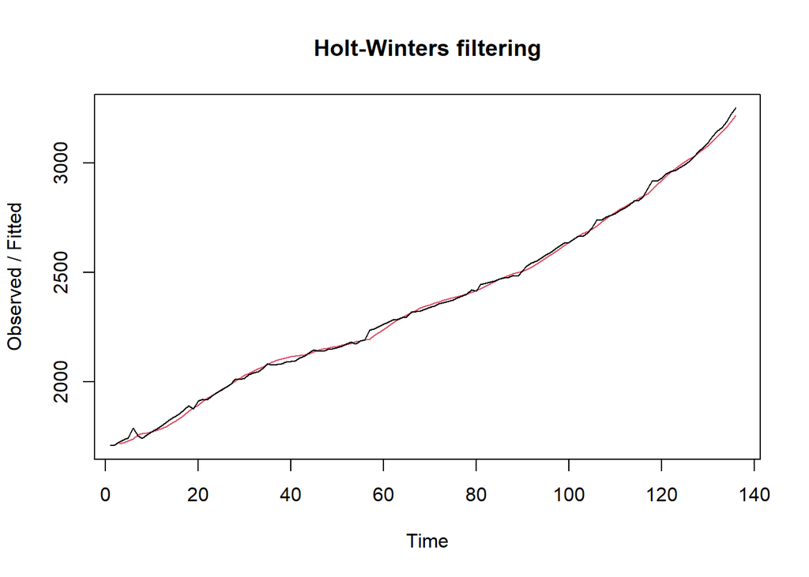

```r
#Lamda=0.2 dan gamma=0.2
des.1<- HoltWinters(train.ts, gamma = FALSE, beta = 0.2, alpha = 0.2)
plot(des.1)
```

```r
#ramalan
ramalandes1<- forecast(des.1, h=35)
ramalandes1
```

```
##     Point Forecast    Lo 80    Hi 80    Lo 95    Hi 95
## 137       3248.405 3230.202 3266.607 3220.566 3276.243
## 138       3270.869 3252.149 3289.588 3242.240 3299.498
## 139       3293.333 3273.932 3312.734 3263.662 3323.004
## 140       3315.797 3295.541 3336.054 3284.817 3346.777
## 141       3338.261 3316.971 3359.552 3305.701 3370.822
## 142       3360.726 3338.225 3383.226 3326.314 3395.138
## 143       3383.190 3359.306 3407.074 3346.663 3419.717
## 144       3405.654 3380.222 3431.086 3366.760 3444.548
## 145       3428.118 3400.982 3455.254 3386.617 3469.619
## 146       3450.583 3421.595 3479.570 3406.250 3494.915
## 147       3473.047 3442.070 3504.023 3425.672 3520.421
## 148       3495.511 3462.416 3528.606 3444.897 3546.125
## 149       3517.975 3482.641 3553.309 3463.937 3572.014
## 150       3540.439 3502.753 3578.126 3482.804 3598.075
```

[output cut: 21 more lines]

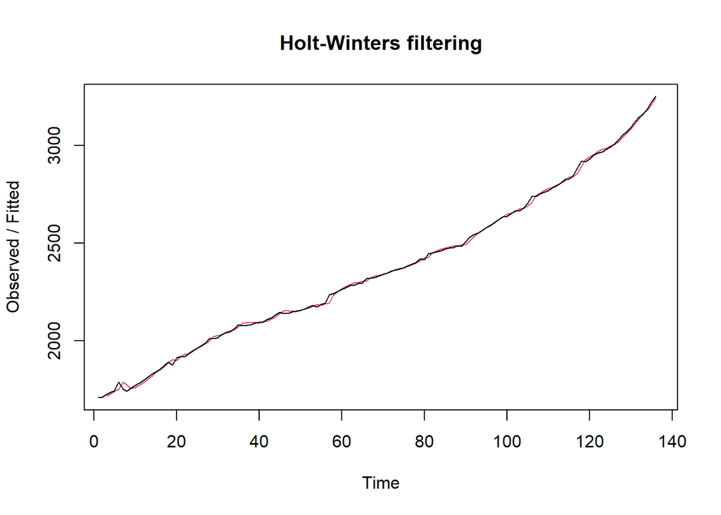

```r
#Lamda=0.6 dan gamma=0.3
des.2<- HoltWinters(train.ts, gamma = FALSE, beta = 0.3, alpha = 0.6)
plot(des.2)
```

```r
#ramalan
ramalandes2<- forecast(des.2, h=35)
ramalandes2
```

```
##     Point Forecast    Lo 80    Hi 80    Lo 95    Hi 95
## 137       3276.280 3262.316 3290.244 3254.924 3297.636
## 138       3303.012 3285.303 3320.722 3275.928 3330.096
## 139       3329.745 3307.534 3351.956 3295.777 3363.714
## 140       3356.478 3329.152 3383.804 3314.686 3398.270
## 141       3383.211 3350.249 3416.172 3332.800 3433.621
## 142       3409.943 3370.889 3448.997 3350.216 3469.671
## 143       3436.676 3391.118 3482.234 3367.001 3506.351
## 144       3463.409 3410.967 3515.850 3383.206 3543.611
## 145       3490.141 3430.462 3549.820 3398.870 3581.412
## 146       3516.874 3449.624 3584.124 3414.024 3619.724
## 147       3543.607 3468.469 3618.744 3428.693 3658.520
## 148       3570.339 3487.011 3653.668 3442.900 3697.779
## 149       3597.072 3505.263 3688.881 3456.662 3737.482
## 150       3623.805 3523.235 3724.375 3469.996 3777.613
```

[output cut: 21 more lines]

Selanjutnya jika ingin membandingkan plot data latih dan data uji adalah sebagai berikut.

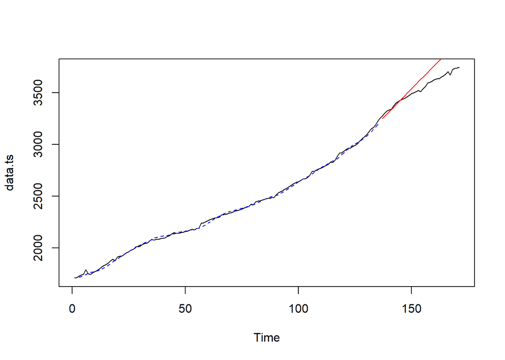

```r
plot(data.ts)
lines(des.1$fitted[,1], lty=2, col="blue")
lines(ramalandes1$mean, col="red")
```

Untuk mendapatkan nilai parameter optimum dari DES, argumen `alpha` dan `beta` dapat dibuat `NULL` seperti berikut.

```r
#Lamda dan gamma optimum
des.opt<- HoltWinters(train.ts, gamma = FALSE)
des.opt
```

```
## Holt-Winters exponential smoothing with trend and without seasonal component.
##
## Call:
## HoltWinters(x = train.ts, gamma = FALSE)
##
## Smoothing parameters:
##  alpha: 0.863695
##  beta : 0.1020933
##  gamma: FALSE
##
## Coefficients:
##         [,1]
## a 3251.55610
## b   21.39451
```

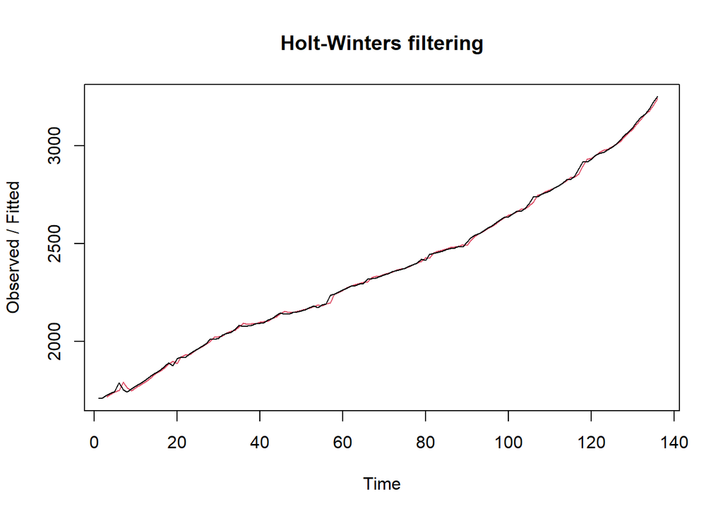

```r
plot(des.opt)
```

```r
#ramalan
ramalandesopt<- forecast(des.opt, h=35)
ramalandesopt
```

```
##     Point Forecast    Lo 80    Hi 80    Lo 95    Hi 95
## 137       3272.951 3259.722 3286.179 3252.719 3293.182
## 138       3294.345 3276.081 3312.609 3266.413 3322.277
## 139       3315.740 3292.873 3338.606 3280.769 3350.711
## 140       3337.134 3309.828 3364.440 3295.373 3378.895
## 141       3358.529 3326.834 3390.224 3310.055 3407.002
## 142       3379.923 3343.834 3416.012 3324.730 3435.117
## 143       3401.318 3360.798 3441.838 3339.347 3463.288
## 144       3422.712 3377.704 3467.720 3353.879 3491.546
## 145       3444.107 3394.543 3493.671 3368.305 3519.908
## 146       3465.501 3411.305 3519.698 3382.615 3548.387
## 147       3486.896 3427.986 3545.806 3396.800 3576.991
## 148       3508.290 3444.581 3571.999 3410.856 3605.725
## 149       3529.685 3461.090 3598.279 3424.779 3634.591
## 150       3551.079 3477.512 3624.647 3438.567 3663.591
```

[output cut: 21 more lines]

Selanjutnya akan dilakukan perhitungan akurasi pada data latih maupun data uji dengan ukuran akurasi SSE, MSE dan MAPE.

#### Akurasi Data Latih

```r
#Akurasi Data Training
ssedes.train1<-des.1$SSE
msedes.train1<-ssedes.train1/length(train.ts)
sisaandes1<-ramalandes1$residuals
head(sisaandes1)
```

```
## Time Series:
## Start = 1
## End = 6
## Frequency = 1
## [1]       NA       NA  8.90000 13.36400 14.10064 47.52593
```

```r
mapedes.train1 <- sum(abs(sisaandes1[3:length(train.ts)]/train.ts[3:length(train.ts)])
                      *100)/length(train.ts)

akurasides.1 <- matrix(c(ssedes.train1,msedes.train1,mapedes.train1))
row.names(akurasides.1)<- c("SSE", "MSE", "MAPE")
colnames(akurasides.1) <- c("Akurasi lamda=0.2 dan gamma=0.2")
akurasides.1
```

```
##      Akurasi lamda=0.2 dan gamma=0.2
## SSE                     2.835379e+04
## MSE                     2.084837e+02
## MAPE                    4.875019e-01
```

```r
ssedes.train2<-des.2$SSE
msedes.train2<-ssedes.train2/length(train.ts)
sisaandes2<-ramalandes2$residuals
head(sisaandes2)
```

```
## Time Series:
## Start = 1
## End = 6
## Frequency = 1
## [1]       NA       NA  8.90000  8.55800  4.58076 35.56533
```

```r
mapedes.train2 <- sum(abs(sisaandes2[3:length(train.ts)]/train.ts[3:length(train.ts)])
                      *100)/length(train.ts)

akurasides.2 <- matrix(c(ssedes.train2,msedes.train2,mapedes.train2))
row.names(akurasides.2)<- c("SSE", "MSE", "MAPE")
colnames(akurasides.2) <- c("Akurasi lamda=0.6 dan gamma=0.3")
akurasides.2
```

```
##      Akurasi lamda=0.6 dan gamma=0.3
## SSE                     1.590506e+04
## MSE                     1.169489e+02
## MAPE                    3.415561e-01
```

Hasil akurasi dari data latih didapatkan skenario 2 dengan lamda=0.6 dan gamma=0.3 memiliki hasil yang lebih baik. Namun untuk kedua skenario dapat dikategorikan peramalan sangat baik berdasarkan nilai MAPE-nya.

#### Akurasi Data Uji

```r
#Akurasi Data Testing
selisihdes1<-ramalandes1$mean-testing$jmlh_pegawai
selisihdes1
```

```
## Time Series:
## Start = 137
## End = 171
## Frequency = 1
##  [1] -27.295480 -29.631254 -27.867028 -17.202802  -1.338576 -12.874350
##  [7] -14.810124  -9.245897  -1.281671  12.782555  25.246781  34.711007
## [13]  44.175233  48.739459  63.803685  72.367911  84.632137 117.096363
## [19] 111.960589 113.124815 103.289041 118.253267 128.617493 138.581719
## [25] 154.045945 174.110171 179.674397 189.438623 193.902849 197.567075
## [31] 253.031301 218.795527 230.259753 248.723979 266.388206
```

```r
SSEtestingdes1<-sum(selisihdes1^2)
MSEtestingdes1<-SSEtestingdes1/length(testing$jmlh_pegawai)
MAPEtestingdes1<-sum(abs(selisihdes1/testing$jmlh_pegawai)*100)/length(testing$jmlh_pegawai)

selisihdes2<-ramalandes2$mean-testing$jmlh_pegawai
selisihdes2
```

```
## Time Series:
## Start = 137
## End = 171
## Frequency = 1
##  [1]   0.5797436   2.5124370   8.5451304  23.4778238  43.6105172  36.3432107
##  [7]  38.6759041  48.5085975  60.7412909  79.0739843  95.8066778 109.5393712
## [13] 123.2720646 132.1047580 151.4374514 164.2701449 180.8028383 217.5355317
## [19] 216.6682251 222.1009185 216.5336120 235.7663054 250.3989988 264.6316922
## [25] 284.3643856 308.6970791 318.5297725 332.5624659 341.2951593 349.2278527
## [31] 408.9605462 378.9932396 394.7259330 417.4586264 439.3913198
```

```r
SSEtestingdes2<-sum(selisihdes2^2)
MSEtestingdes2<-SSEtestingdes2/length(testing$jmlh_pegawai)
MAPEtestingdes2<-sum(abs(selisihdes2/testing$jmlh_pegawai)*100)/length(testing$jmlh_pegawai)

selisihdesopt<-ramalandesopt$mean-testing$jmlh_pegawai
selisihdesopt
```

```
## Time Series:
## Start = 137
## End = 171
## Frequency = 1
##  [1]  -2.749389  -6.154876  -5.460363   4.134150  18.928664   6.323177
##  [7]   3.317690   7.812203  14.706717  27.701230  39.095743  47.490256
## [13]  55.884770  59.379283  73.373796  80.868309  92.062823 123.457336
## [19] 117.251849 117.346363 106.440876 120.335389 129.629902 138.524416
## [25] 152.918929 171.913442 176.407955 185.102469 188.496982 191.091495
## [31] 245.486008 210.180522 220.575035 237.969548 254.564061
```

```r
SSEtestingdesopt<-sum(selisihdesopt^2)
MSEtestingdesopt<-SSEtestingdesopt/length(testing$jmlh_pegawai)
MAPEtestingdesopt<-sum(abs(selisihdesopt/testing$jmlh_pegawai)*100)/length(testing$jmlh_pegawai)

akurasitestingdes <-
  matrix(c(SSEtestingdes1,MSEtestingdes1,MAPEtestingdes1,SSEtestingdes2,MSEtestingdes2,
           MAPEtestingdes2,SSEtestingdesopt,MSEtestingdesopt,MAPEtestingdesopt),
         nrow=3,ncol=3)
row.names(akurasitestingdes)<- c("SSE", "MSE", "MAPE")
colnames(akurasitestingdes) <- c("des ske1","des ske2","des opt")
akurasitestingdes
```

```
##          des ske1     des ske2      des opt
## SSE  6.220042e+05 1.993564e+06 6.018343e+05
## MSE  1.777155e+04 5.695896e+04 1.719527e+04
## MAPE 2.883583e+00 5.439963e+00 2.857595e+00
```

#### Perbandingan SES dan DES

```r
MSEfull <-
  matrix(c(MSEtesting1,MSEtesting2,MSEtestingopt,MSEtestingdes1,MSEtestingdes2,
           MSEtestingdesopt),nrow=3,ncol=2)
row.names(MSEfull)<- c("ske 1", "ske 2", "ske opt")
colnames(MSEfull) <- c("ses","des")
MSEfull
```

```
##               ses      des
## ske 1   163505.13 17771.55
## ske 2   104714.94 56958.96
## ske opt  97527.32 17195.27
```

#### Perbandingan SMA, DMA, SES, DES

**Perbandingan Berdasarkan MSE**

```r
perbandingan_akhir <- data.frame(
  Metode = c("SMA (m=3)", "DMA (m=3)",
             "SES (lamda=0.2)", "SES (lamda=0.7)", "SES (optimal)",
             "DES (ske1)", "DES (ske2)", "DES (optimal)"),
  MSE_Uji = c(MSE_test.sma, MSE_test.dma,
              MSEtesting1, MSEtesting2, MSEtestingopt,
              MSEtestingdes1, MSEtestingdes2, MSEtestingdesopt)
)

perbandingan_akhir[order(perbandingan_akhir$MSE_Uji), ]
```

```
##            Metode   MSE_Uji
## 8   DES (optimal)  17195.27
## 6      DES (ske1)  17771.55
## 7      DES (ske2)  56958.96
## 2       DMA (m=3)  78775.89
## 5   SES (optimal)  97527.32
## 4 SES (lamda=0.7) 104714.94
## 1       SMA (m=3) 115542.50
## 3 SES (lamda=0.2) 163505.13
```

**Perbandingan Berdasarkan MAPE**

```r
perbandingan_akhir_mape <- data.frame(
  Metode = c("SMA (m=3)", "DMA (m=3)",
             "SES (lamda=0.2)", "SES (lamda=0.7)", "SES (optimal)",
             "DES (ske1)", "DES (ske2)", "DES (optimal)"),
  MAPE_Uji = c(MAPE_test.sma, MAPE_test.dma,
               MAPEtesting1, MAPEtesting2, MAPEtestingopt,
               MAPEtestingdes1, MAPEtestingdes2, MAPEtestingdesopt)
)

perbandingan_akhir_mape[order(perbandingan_akhir_mape$MAPE_Uji), ]
```

```
##            Metode  MAPE_Uji
## 8   DES (optimal)  2.857595
## 6      DES (ske1)  2.883583
## 7      DES (ske2)  5.439963
## 2       DMA (m=3)  6.473561
## 5   SES (optimal)  7.806681
## 4 SES (lamda=0.7)  8.161533
## 1       SMA (m=3)  8.669179
## 3 SES (lamda=0.2) 10.634269
```

# Kesimpulan Metode Terbaik Untuk Data

Berdasarkan nilai MSE maupun MAPE pada data uji, kedua metrik akurasi menunjukkan urutan peringkat metode yang konsisten. **Metode Double Exponential Smoothing (DES)** dengan parameter optimal memberikan hasil peramalan terbaik (MSE = 17.195,27 & MAPE = 2,86%). Dengan demikian, hasil dari MSE dan MAPE memperkuat kesimpulan bahwa Metode DES optimal merupakan metode pemulusan terbaik untuk data jumlah pegawai pendidikan pemerintah daerah pada bagian data ini, sesuai dengan karakteristik data yang memiliki pola tren jangka panjang.